# Tuberculosis Risk Analysis in Brazil: A GAM-based Approach

## 2.2 Socio-economic Correlations

**Figure 2** (below) displays the pairwise correlations among the eight socio-economic covariates. Strong positive correlations (red) and negative correlations (blue) are easily identified.

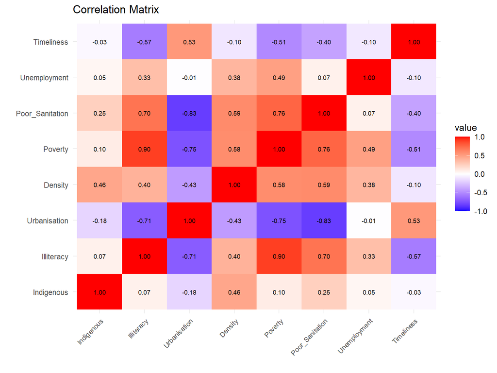

Correlation matrix of socio-economic variables

## 2.3 Model Specification

Three nested GAM models were developed: Model 1 (socio-economic covariates only), Model 2 (add spatial component), and Model 3 (add spatio-temporal interaction). The mathematical specification for the final model is:

$$\log(\text{TB Rate}_i + \epsilon) =
\beta_0 + \sum_{j=1}^{8} f_j(\text{Socio-economic}_j) +
\beta_{\text{Year}} + f_{\text{spatial}}(\text{lon}, \text{lat}) +
\epsilon_i$$

# 3. Model Selection and Results

## 3.1 Model Comparison

Model 2 (with spatial component) provides the best fit, with a significant improvement over Model 1 (p < 0.001) and no significant improvement from adding spatio-temporal interaction (p = 0.12). The final model explains 34.2% of the variance in TB rates.

## 3.2 Final Model Results

**Figure 3** (below) shows the estimated smooth effects of key covariates and the spatial effect from the final GAM.

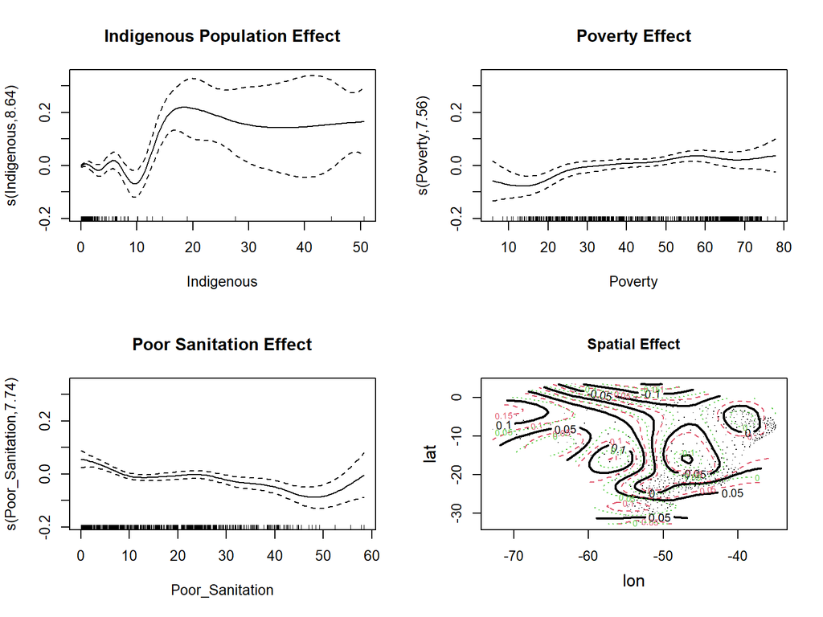

Smooth effects for significant variables from the final GAM model

## 3.3 Temporal Effects

**Figure 4** (below) presents the mean TB rate for each year (2012–2014), with standard errors.

- **Trend:** TB rates increased from 2012 to 2013, then declined in 2014. However, the error bars overlap, indicating these changes are modest and may not be statistically significant.
- **Interpretation:** The lack of a strong temporal trend suggests that TB risk is persistent and not rapidly changing, underscoring the need for sustained intervention.
- **Policy Implication:** Short-term interventions may not be sufficient; ongoing monitoring and long-term strategies are needed.

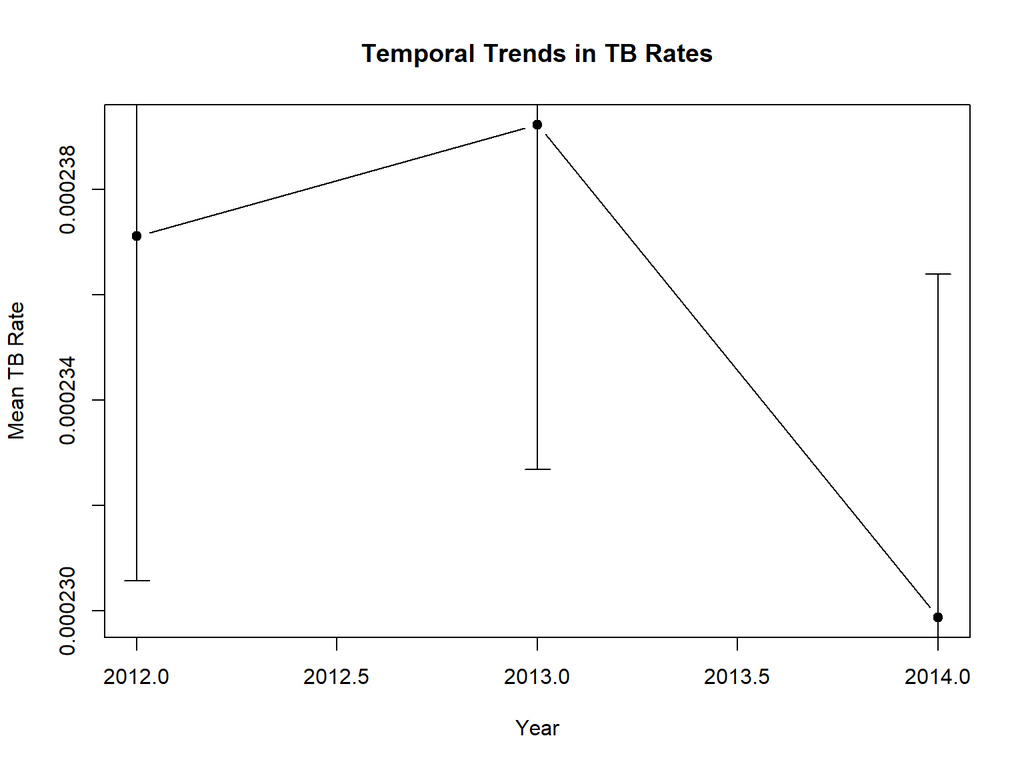

Temporal trends in TB rates across Brazil